# Untitled

2026-07-16

## Carga de datos

¿Cómo visualizamos los primeros datos del conjunto?

```
##   PassengerId Survived Pclass
## 1           1        0      3
## 2           2        1      1
## 3           3        1      3
## 4           4        1      1
## 5           5        0      3
## 6           6        0      3
##                                                  Name    Sex Age SibSp Parch
## 1                             Braund, Mr. Owen Harris   male  22     1     0
## 2 Cumings, Mrs. John Bradley (Florence Briggs Thayer) female  38     1     0
## 3                              Heikkinen, Miss. Laina female  26     0     0
## 4        Futrelle, Mrs. Jacques Heath (Lily May Peel) female  35     1     0
## 5                            Allen, Mr. William Henry   male  35     0     0
## 6                                    Moran, Mr. James   male  NA     0     0
##             Ticket    Fare Cabin Embarked
## 1        A/5 21171  7.2500              S
## 2         PC 17599 71.2833   C85        C
## 3 STON/O2. 3101282  7.9250              S
## 4           113803 53.1000  C123        S
## 5           373450  8.0500              S
## 6           330877  8.4583              Q
```

¿Como hacemos para saber de que tipo son los datos (texto/numero)?

```
## 'data.frame':    891 obs. of  12 variables:
##  $ PassengerId: int  1 2 3 4 5 6 7 8 9 10 ...
##  $ Survived   : int  0 1 1 1 0 0 0 0 1 1 ...
##  $ Pclass     : int  3 1 3 1 3 3 1 3 3 2 ...
##  $ Name       : chr  "Braund, Mr. Owen Harris" "Cumings, Mrs. John Bradley (Florence Briggs Thayer)" "Heikkinen, Miss. Laina" "Futrelle, Mrs. Jacques Heath (Lily May Peel)" ...
##  $ Sex        : chr  "male" "female" "female" "female" ...
##  $ Age        : num  22 38 26 35 35 NA 54 2 27 14 ...
##  $ SibSp      : int  1 1 0 1 0 0 0 3 0 1 ...
##  $ Parch      : int  0 0 0 0 0 0 0 1 2 0 ...
##  $ Ticket     : chr  "A/5 21171" "PC 17599" "STON/O2. 3101282" "113803" ...
##  $ Fare       : num  7.25 71.28 7.92 53.1 8.05 ...
##  $ Cabin      : chr  "" "C85" "" "C123" ...
##  $ Embarked   : chr  "S" "C" "S" "S" ...
```

## Limpieza de datos

¿Cuantos datos faltantes hay para la variable edad (Age)?

```
## [1] 177
```

Si los eliminamos perdemos demasiada información ¿Que hacemos?

Solucion: **Imputarlos** (imputar a la Media o a la Mediana) Recordatorio: La media se ve afectada por los *valores atípicos (outliers)*

```
## [1] NA
```

## Analisis exploratorio de datos (EDA) con gráficos

¿Como determinamos si los niños (Age < 12) sobrevivieron más?

## Nivel 1: R Base (Sin incluir ningun paquete)

Ideal para entender la logica sin dependencias

# Tabla de contingencia (Frecuencias)

¿Cuantos hombres y mujeres sobrevivieron?

```
##
##            0   1
##   female  81 233
##   male   468 109
```

```
##
##                 0        1
##   female 25.79618 74.20382
##   male   81.10919 18.89081
```

## Box Plot (Edad Vs. Supervivencia)

¿La edad de los que sobrevivieron es similar a la de las que no lo hicieron?

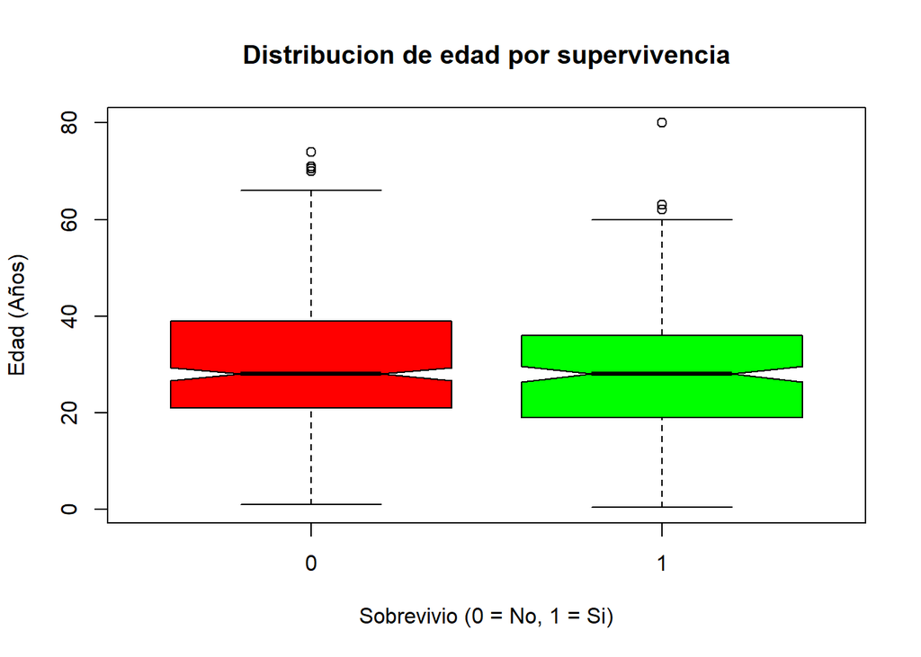

## Barplot

¿La clase influyo en la supervivencia?

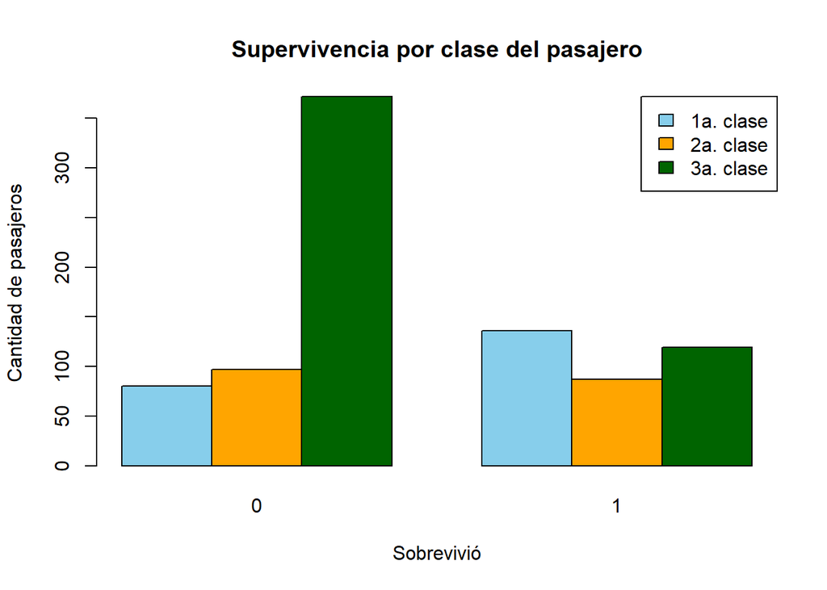

### Gráfico de barras apilado (Porcentual) ¿Qué porcentaje de cada clase sobrevivió?

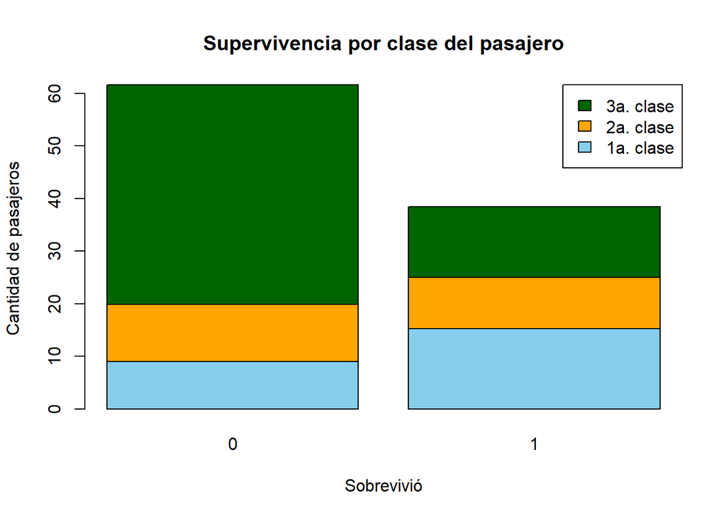

## Nivel 2: GGPLOT2 (Más profesional y estético)

### Boxplot con ggplot2

¿Qué grupo tiene mayor edad? (observar las medianas)

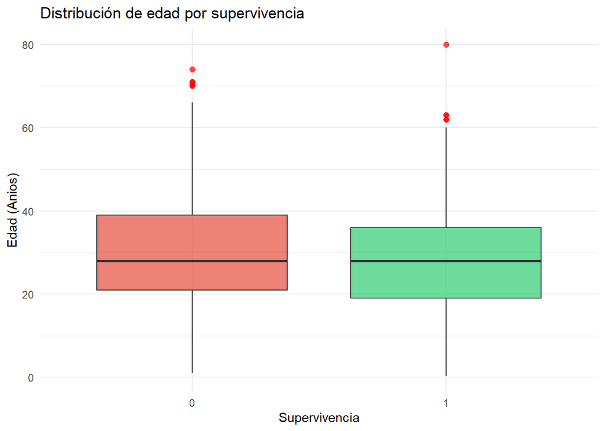

### Gráfico de barras

¿Cuantos sobrevivieron en cada clase?

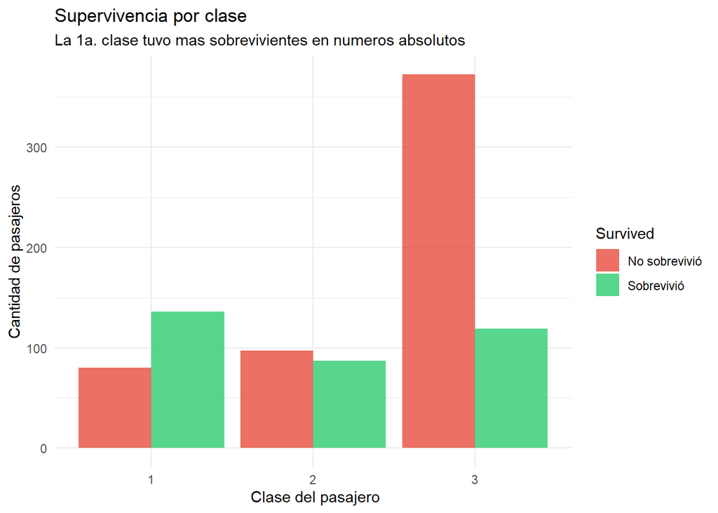

### Gráfico de barras

¿Cuantos sobrevivieron en cada clase?

[figure not shown]

### Relación entre Edad, Clase y Supervivencia (Mas avanzado) ¿Los niños de la 3a clase tuvieron la misma oportunidad de supervivencia que los niños de la 1a clase?

[figure not shown]

## Nivel 3: DPLYR + GGPLOT2 (flujo de trabajo profesional) Encadenar procesos de trabajo (pipe) 1. Calcular la tasa de supervivencia por el género y clase.

```
## # A tibble: 6 × 6
##   Sex    Pclass Sobrevivieron Total Tasa_supervivencia Edad_media
##   <fct>  <fct>          <int> <int>              <dbl>      <dbl>
## 1 female 1                 91    94               96.8       34.6
## 2 female 2                 70    76               92.1       28.7
## 3 female 3                 72   144               50         21.8
## 4 male   1                 45   122               36.9       41.3
## 5 male   2                 17   108               15.7       30.7
## 6 male   3                 47   347               13.5       26.5
```

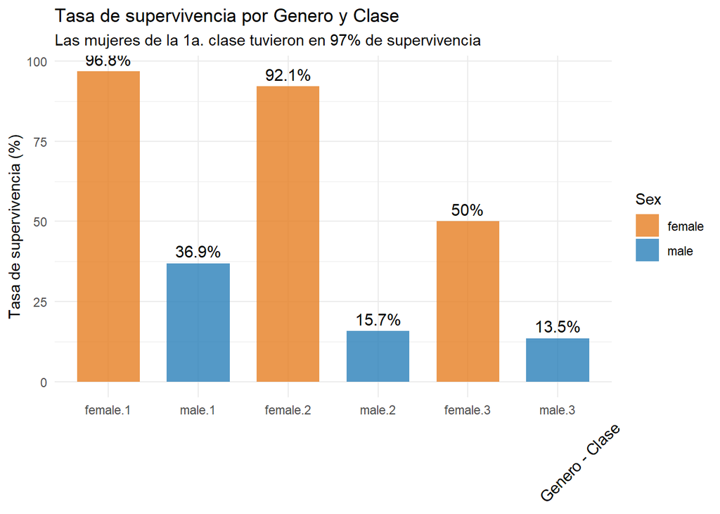

## Visualizaciones múltiples

### Con GGPLOT y GridExtra

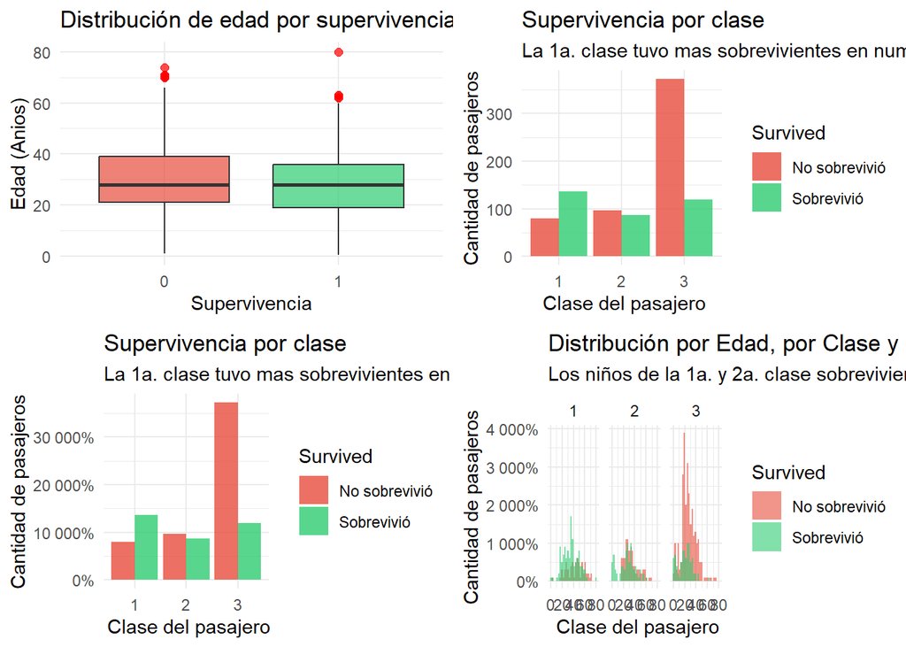

### Con R base

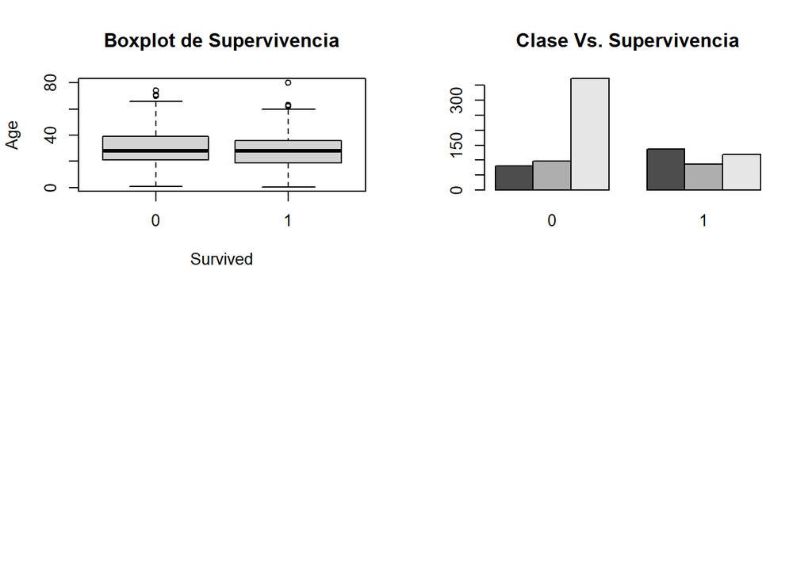